# Informe: Análisis movilidad en Venezuela

Alvarorondon

April 22

# 1 Consideraciones del informe:

Este informe presenta un análisis de la **movilidad en Venezuela**.

La data presenta observaciones desde **Febrero 2020** hasta **Abril 2022**

El conjunto de datos presenta información sobre variaciones de la movilidad de los usuarios respecto al período **enero - febrero 2020** de acuerdo a diferentes ubicaciónes:

1. Tiendas y Ocio.
2. Supermercados y farmacias.
3. Lugares de trabajo.
4. Zonas residenciales.
5. Estaciones de transporte.
6. Parques.

Google construye el indicador en función de los usuarios que decidieron dar acceso a la plataforma a su ubicación.

La información se obtuvo de [Google mobility report.](https://www.google.com/covid19/mobility/)

# 2 Movilidad según ubicación

Se presentan los gráficos de la evolución de la movilidad en Venezuela, **la linea verde en cada grafico representa la base de comparación.**

## 2.1 Tiendas y ocio

[interactive chart not shown]

## 2.2 Supermercados y farmacias

[interactive chart not shown]

## 2.3 Lugares de trabajo

[interactive chart not shown]

## 2.4 Zonas residenciales

[interactive chart not shown]

## 2.5 Estaciones de transporte

[interactive chart not shown]

## 2.6 Parques

[interactive chart not shown]

## 2.7 Análisis

La movilidad en Venezuela presenta una tendencia creciente para todas las ubicaciones analizadas salvo para la movilidad en zonas residenciales, en algunos casos como en el de la movilidad en parques y en tiendas y ocio esta es igual o mayor a los niveles precuarentena.

Para el caso de los lugares de trabajo la movilidad presenta un comportamiento ciclico con tendencia, registrandose incrementos en la magnitud de la variación los fines de semana (sábados y domingos).

La movilidad en las zonas residenciales presenta una ligera tendencia a la baja, sin embargo, las magnitudes de los incrementos superan con creces a los registrados antes de la cuarentena.

# 3 Correlación entre movilidad en Venezuela según ubicación y año

A continuación se presentan las matrices de correlación para el año 2020 y el año 2021, el objetivo es describir si existe relación líneal entre las variaciones según el año.

Solo se considerarán los períodos desde que se detectó el primer caso de **COVID-19** a nivel nacional.

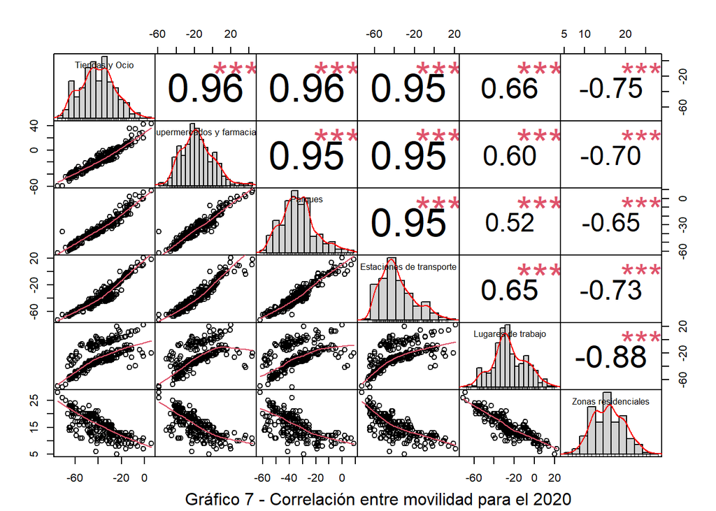

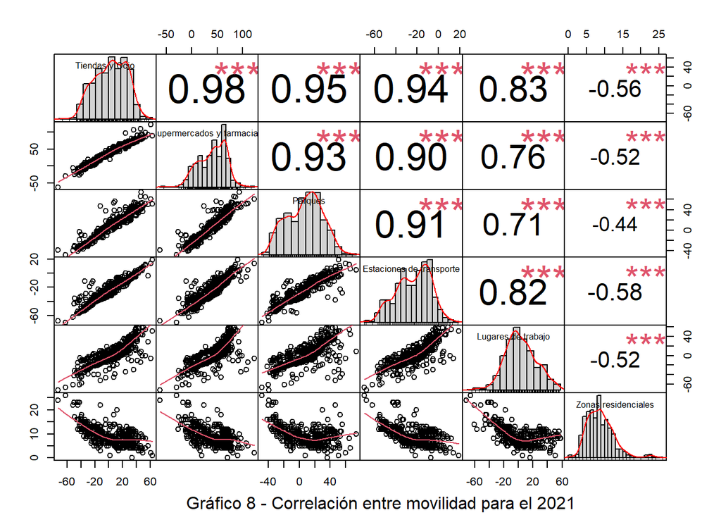

[figure not shown]

# 4 Análisis de acuerdo al día de la semana para la movilidad en Venezuela

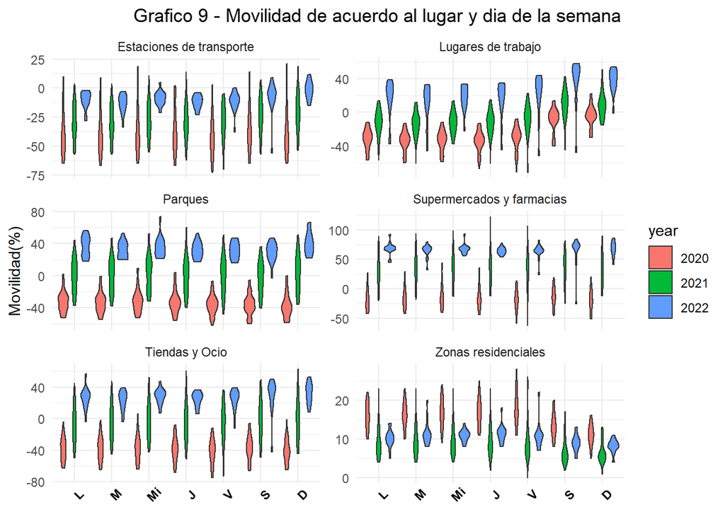

Observando el comportamiento de la movilidad se puede apreciar:

1. Para algunas ubicaciones (lugares de trabajo y zonas residenciales ) **existen dias en el que las magnitudes de las variaciones son más altas (para lugares de trabajo)**, siendo esto visible durante los fines de semana (sábados y domingos).
2. El comportamiento entre las variaciones en lugares de trabajo y zonas residenciales de acuerdo al dia es inverso (los dias en que una de ellas tiene incrementos de mayor magnitud la otra parece tener variaciones de menor magnitud).
3. Las magnitudes de incremento de acuerdo al día de la semana **son mayores para el año 2021 que las registradas para el 2020** salvo en las registradas en la ubicación **zonas residenciales**.